# Association Rule Mining

### Goal

The goal is to find useful associations between different items that are purchased together.

### Data Exploration

Some interesting finds from summary of all transactions:

1. There are a total of 9835 transactions and 169 items in the itemset.
2. 2159 (~22%) of the times only one product is bought.
3. 75% of the baskets have 6 items or less.
4. Whole milk, other vegetables, rolls/buns, soda and yogurt are the top five most frequently bought items with presence in 2513 (25.5%), 1903 (19.4%), 1809 (18.4%), 1715 (17.4%) and 1372 (13.9%) transactions/baskets respectively.

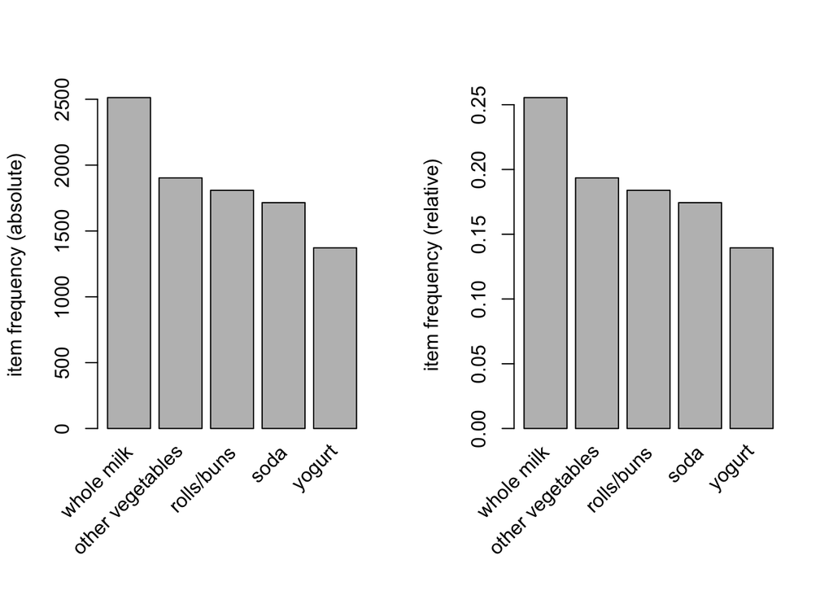

### Selection of support and confidence thresholds

We will try different threshold for support and confidence to see the variation in number of rules generated and select values for support and confidence thresholds that give decent number of rules.  
Another point to note here is that the maximum antecedent length that we’ll take is 4 because in a real world scenario it is difficult to couple more items together. This is an assumption though.

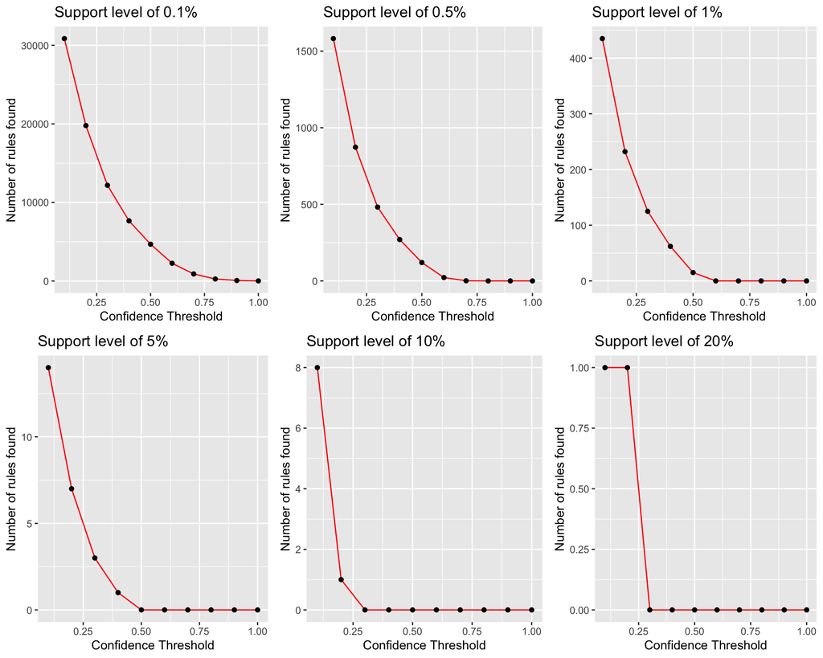

Analyzing the plots, we find that for a given threshold of support, number of rules generated decrease exponentially with increase in confidence ultimately reaching to 0. In addition to this, support threshold of 5% or greater give very less number of rules.  
We will use support thresold equal to 0.005 i.e. consider baskets that appear in more than or eual to 0.5% of the transactions and confidence threshold of 0.3 i.e. consider associations between X (antecedent) and Y (consequent) X=>Y where probability of Y being purchased when X is purchased is more than or equal to 0.3. This will give us sufficient number of rules to work with

### Getting Association Rules using Apriori Algorithm

We get 482 rules in total.  
Let’s see what the consequents and their frequencies are.

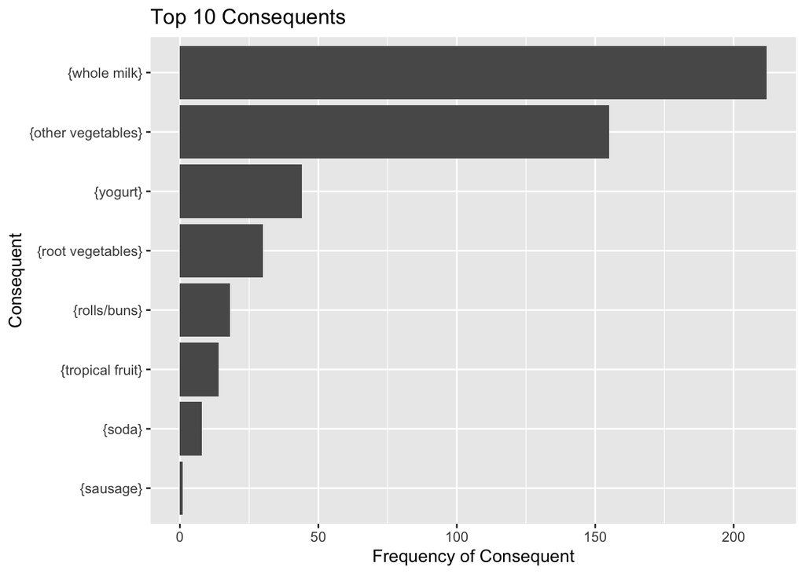

As we observe from the plot above, most frequent consequent is whole milk followed by other vegetables. This was highly likely as whole milk and other vegetables are present in 25.5% and 19.4% of the transactions. These are frequently consumed perishable items. Hence, most of the transactions and resultant associations were expected to be skewed because of their presence.

We will now do a two-key plotting to understand the distribution of baskets based on their confidence, support and order.

```
## To reduce overplotting, jitter is added! Use jitter = 0 to prevent jitter.
```

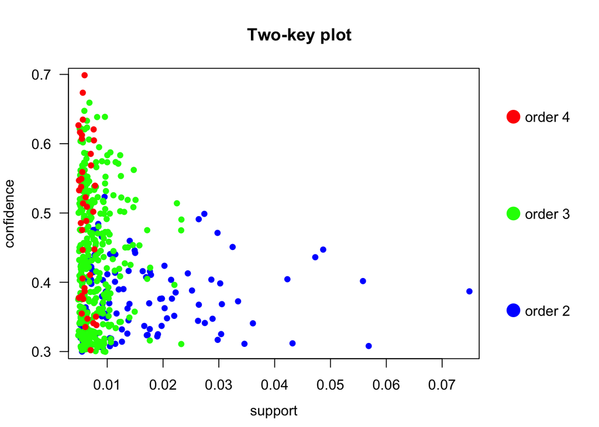

From the plot we can observe that most of the rules of order 2 have high support and confidence ranging from low to moderate. Let’s filter the rules where order is 2 and lift is greater than 2.

|  | lhs | rhs | support | confidence | lift | count |
| --- | --- | --- | --- | --- | --- | --- |
| 8 | {herbs} | {root vegetables} | 0.0070158 | 0.4312500 | 3.956477 | 69 |
| 72 | {beef} | {root vegetables} | 0.0173869 | 0.3313953 | 3.040367 | 171 |
| 46 | {onions} | {root vegetables} | 0.0094560 | 0.3049180 | 2.797452 | 93 |
| 23 | {soft cheese} | {yogurt} | 0.0059990 | 0.3511905 | 2.517462 | 59 |
| 9 | {herbs} | {other vegetables} | 0.0077275 | 0.4750000 | 2.454874 | 76 |
| 47 | {onions} | {other vegetables} | 0.0142349 | 0.4590164 | 2.372268 | 140 |
| 40 | {sliced cheese} | {yogurt} | 0.0080325 | 0.3278008 | 2.349797 | 79 |
| 75 | {curd} | {yogurt} | 0.0172852 | 0.3244275 | 2.325615 | 170 |
| 49 | {berries} | {yogurt} | 0.0105745 | 0.3180428 | 2.279848 | 104 |
| 104 | {root vegetables} | {other vegetables} | 0.0473818 | 0.4347015 | 2.246605 | 466 |
| 61 | {cream cheese} | {yogurt} | 0.0124047 | 0.3128205 | 2.242412 | 122 |
| 35 | {butter milk} | {yogurt} | 0.0085409 | 0.3054545 | 2.189610 | 84 |
| 64 | {chicken} | {other vegetables} | 0.0178953 | 0.4170616 | 2.155439 | 176 |
| 25 | {soft cheese} | {other vegetables} | 0.0071174 | 0.4166667 | 2.153398 | 70 |
| 52 | {hamburger meat} | {other vegetables} | 0.0138282 | 0.4159021 | 2.149447 | 136 |
| 19 | {baking powder} | {other vegetables} | 0.0073208 | 0.4137931 | 2.138547 | 72 |
| 27 | {grapes} | {other vegetables} | 0.0090493 | 0.4045455 | 2.090754 | 89 |
| 92 | {whipped/sour cream} | {other vegetables} | 0.0288765 | 0.4028369 | 2.081924 | 284 |
| 20 | {baking powder} | {whole milk} | 0.0092527 | 0.5229885 | 2.046794 | 91 |

Interesting points to note here are:

1. People who buy baking powder have a high probability of buying whole milk and/or other vegetables. These people could be regulars to the grocery store buying milk and vegetables on regular basis but seldom buying baking powder. This can be substantiated by low support for baking powder.
2. People tend to buy yogurt as well when they buy other diary products.

Let’s filter the rules where order is 3 and lift is greater than 2.

|  | lhs | rhs | support | confidence | lift | count |
| --- | --- | --- | --- | --- | --- | --- |
| 309 | {citrus fruit,pip fruit} | {tropical fruit} | 0.0055923 | 0.4044118 | 3.854060 | 55 |
| 168 | {curd,tropical fruit} | {yogurt} | 0.0052872 | 0.5148515 | 3.690645 | 52 |
| 157 | {beef,other vegetables} | {root vegetables} | 0.0079309 | 0.4020619 | 3.688693 | 78 |
| 113 | {onions,other vegetables} | {root vegetables} | 0.0056940 | 0.4000000 | 3.669776 | 56 |
| 159 | {beef,whole milk} | {root vegetables} | 0.0080325 | 0.3779904 | 3.467851 | 79 |
| 317 | {other vegetables,pip fruit} | {tropical fruit} | 0.0094560 | 0.3618677 | 3.448613 | 93 |
| 315 | {pip fruit,yogurt} | {tropical fruit} | 0.0064057 | 0.3559322 | 3.392048 | 63 |
| 351 | {citrus fruit,other vegetables} | {root vegetables} | 0.0103711 | 0.3591549 | 3.295046 | 102 |
| 364 | {rolls/buns,shopping bags} | {sausage} | 0.0059990 | 0.3072917 | 3.270794 | 59 |
| 313 | {pip fruit,root vegetables} | {tropical fruit} | 0.0052872 | 0.3398693 | 3.238967 | 52 |
| 292 | {tropical fruit,whipped/sour cream} | {yogurt} | 0.0062023 | 0.4485294 | 3.215224 | 61 |
| 148 | {frozen vegetables,other vegetables} | {root vegetables} | 0.0061007 | 0.3428571 | 3.145522 | 60 |
| 408 | {other vegetables,tropical fruit} | {root vegetables} | 0.0123030 | 0.3427762 | 3.144780 | 121 |
| 133 | {chicken,whole milk} | {root vegetables} | 0.0059990 | 0.3410405 | 3.128855 | 59 |
| 287 | {pip fruit,whipped/sour cream} | {other vegetables} | 0.0055923 | 0.6043956 | 3.123610 | 55 |
| 112 | {onions,root vegetables} | {other vegetables} | 0.0056940 | 0.6021505 | 3.112008 | 56 |
| 345 | {citrus fruit,root vegetables} | {tropical fruit} | 0.0056940 | 0.3218391 | 3.067139 | 56 |
| 350 | {citrus fruit,root vegetables} | {other vegetables} | 0.0103711 | 0.5862069 | 3.029608 | 102 |
| 235 | {butter,other vegetables} | {root vegetables} | 0.0066090 | 0.3299492 | 3.027100 | 65 |
| 407 | {root vegetables,tropical fruit} | {other vegetables} | 0.0123030 | 0.5845411 | 3.020999 | 121 |
| 229 | {butter,whipped/sour cream} | {whole milk} | 0.0067107 | 0.6600000 | 2.583008 | 66 |
| 288 | {pip fruit,whipped/sour cream} | {whole milk} | 0.0059990 | 0.6483516 | 2.537421 | 59 |
| 239 | {butter,yogurt} | {whole milk} | 0.0093543 | 0.6388889 | 2.500387 | 92 |
| 236 | {butter,root vegetables} | {whole milk} | 0.0082359 | 0.6377953 | 2.496107 | 81 |
| 172 | {curd,tropical fruit} | {whole milk} | 0.0065074 | 0.6336634 | 2.479936 | 64 |
| 257 | {domestic eggs,pip fruit} | {whole milk} | 0.0053889 | 0.6235294 | 2.440275 | 53 |
| 233 | {butter,tropical fruit} | {whole milk} | 0.0062023 | 0.6224490 | 2.436047 | 61 |
| 218 | {domestic eggs,margarine} | {whole milk} | 0.0051856 | 0.6219512 | 2.434099 | 51 |
| 227 | {butter,domestic eggs} | {whole milk} | 0.0059990 | 0.6210526 | 2.430582 | 59 |
| 259 | {domestic eggs,tropical fruit} | {whole milk} | 0.0069141 | 0.6071429 | 2.376144 | 68 |

From the rules above, we observe the following:

1. We see a strong association between citrus fruit, pip fruit and tropical fruit where people buying citrus fruit and pip fruit are also buying tropical fruit ~40% of the times with a lift of 3.854 (meaning people who buy citrus fruit and pip fruit are 3.854 times more likely to buy tropical fruit if they see those).
2. We see a trend where the probability of people buying vegetables and fruits together is high.
3. We can also see that people who are buying curd and tropical fruit or whipped/sour cream and tropical fruit tend to buy yogart on an average of ~48% of the times with a lift of over 3.
4. People tend buy whole milk when they buy other dairy products such as butter, curd, yogurt, whipped/sour cream.

Let’s plot the distribution of rules based on support, confidence and lift

```
## To reduce overplotting, jitter is added! Use jitter = 0 to prevent jitter.
```

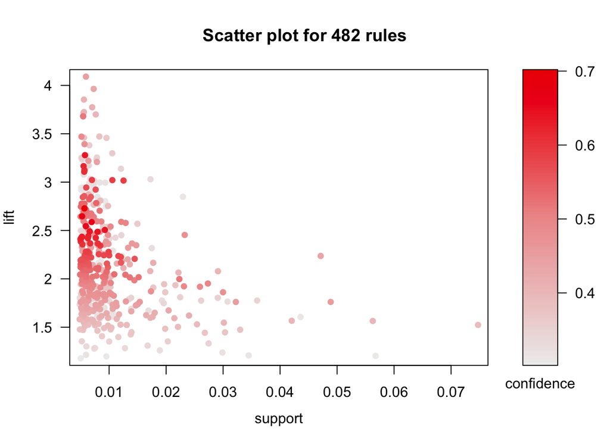

We can see here that some rules have low support and high lift. This might give us a niche category of buyers.  
Filering out these rules:

|  | lhs | rhs | support | confidence | lift | count |
| --- | --- | --- | --- | --- | --- | --- |
| 460 | {citrus fruit,other vegetables,whole milk} | {root vegetables} | 0.0057956 | 0.4453125 | 4.085493 | 57 |
| 8 | {herbs} | {root vegetables} | 0.0070158 | 0.4312500 | 3.956477 | 69 |
| 309 | {citrus fruit,pip fruit} | {tropical fruit} | 0.0055923 | 0.4044118 | 3.854060 | 55 |
| 467 | {other vegetables,tropical fruit,whole milk} | {root vegetables} | 0.0070158 | 0.4107143 | 3.768074 | 69 |
| 464 | {root vegetables,whole milk,yogurt} | {tropical fruit} | 0.0056940 | 0.3916084 | 3.732043 | 56 |
| 454 | {other vegetables,pip fruit,whole milk} | {root vegetables} | 0.0054906 | 0.4060150 | 3.724961 | 54 |
| 168 | {curd,tropical fruit} | {yogurt} | 0.0052872 | 0.5148515 | 3.690645 | 52 |
| 157 | {beef,other vegetables} | {root vegetables} | 0.0079309 | 0.4020619 | 3.688693 | 78 |
| 113 | {onions,other vegetables} | {root vegetables} | 0.0056940 | 0.4000000 | 3.669776 | 56 |
| 445 | {fruit/vegetable juice,other vegetables,whole milk} | {yogurt} | 0.0050839 | 0.4854369 | 3.479790 | 50 |
| 159 | {beef,whole milk} | {root vegetables} | 0.0080325 | 0.3779904 | 3.467851 | 79 |
| 317 | {other vegetables,pip fruit} | {tropical fruit} | 0.0094560 | 0.3618677 | 3.448613 | 93 |
| 463 | {tropical fruit,whole milk,yogurt} | {root vegetables} | 0.0056940 | 0.3758389 | 3.448112 | 56 |
| 462 | {root vegetables,tropical fruit,whole milk} | {yogurt} | 0.0056940 | 0.4745763 | 3.401937 | 56 |
| 315 | {pip fruit,yogurt} | {tropical fruit} | 0.0064057 | 0.3559322 | 3.392048 | 63 |
| 351 | {citrus fruit,other vegetables} | {root vegetables} | 0.0103711 | 0.3591549 | 3.295046 | 102 |
| 459 | {citrus fruit,root vegetables,whole milk} | {other vegetables} | 0.0057956 | 0.6333333 | 3.273165 | 57 |
| 364 | {rolls/buns,shopping bags} | {sausage} | 0.0059990 | 0.3072917 | 3.270794 | 59 |
| 472 | {other vegetables,whole milk,yogurt} | {tropical fruit} | 0.0076258 | 0.3424658 | 3.263712 | 75 |
| 448 | {other vegetables,whipped/sour cream,whole milk} | {root vegetables} | 0.0051856 | 0.3541667 | 3.249281 | 51 |

Interesting obervation here is that some buyers who buy rolls/buns and shopping bags also buy sausage 30% of the times.

### Findings

1. All fruits and vegetables should be kept in close proximity as people often tend to buy them together.
2. Dairy products should be kept together with yogurt being the highlighter product.
3. Berries and yogurt are often brought together. So berries should be placed near dairy section to increase cross-sell.
4. Sausage and rolls/buns may sell together. So they should be kept close to each other.